# PS5: Intro to `ggplot2`

STAT 133

Author

Ian Cheung

**NoteGeneral Instructions**

- Download the template file `ps5.qmd` to answer the questions.
- Rename `ps5.qmd` to `ps5-first-last.qmd`, where `first` and `last` are your first and last names (e.g. `ps5-gaston-sanchez.qmd`).
- Render your qmd file to an HTML file and submit both your qmd and HTML files to the corresponding assignment submission in bCourses.

```r
# load necessary library
# do not remove
library(tidyverse)
```

# 1 Graphics with `"ggplot2"`

In this section we’ll be working with the tibble `mpg` from `"ggplot2"`. These exercises are meant to help you:

- gain familiarity with the `aes()` function
- learn about the various ‘geoms’, or geometric objects, and recognize them
- understand why and how to facet
- try out different plot themes

You should have already loaded the package tidyverse. Type `View(mpg)` in the console to take a look at `mpg`. You can also look at the documentation for `mpg` by typing in `?mpg`.

## 1.1 Aesthetic Mapping Function `aes()`

Let’s first take a look at the relationship between engine displacement, or `displ`, and highway miles per gallon, `hwy`.

```r
ggplot(data = mpg, aes(x = displ, y = hwy)) +
  geom_point()
```

[output not shown]

### 1.1.1 Using `aes()`

Does anything happen if you don’t name the arguments to `aes()`, i.e. you type in `aes(displ, hwy)`? What if you type in `aes(hwy, displ)`?

```r
# your code here
ggplot(data = mpg, aes(displ, hwy)) + geom_point()
```

[output not shown]

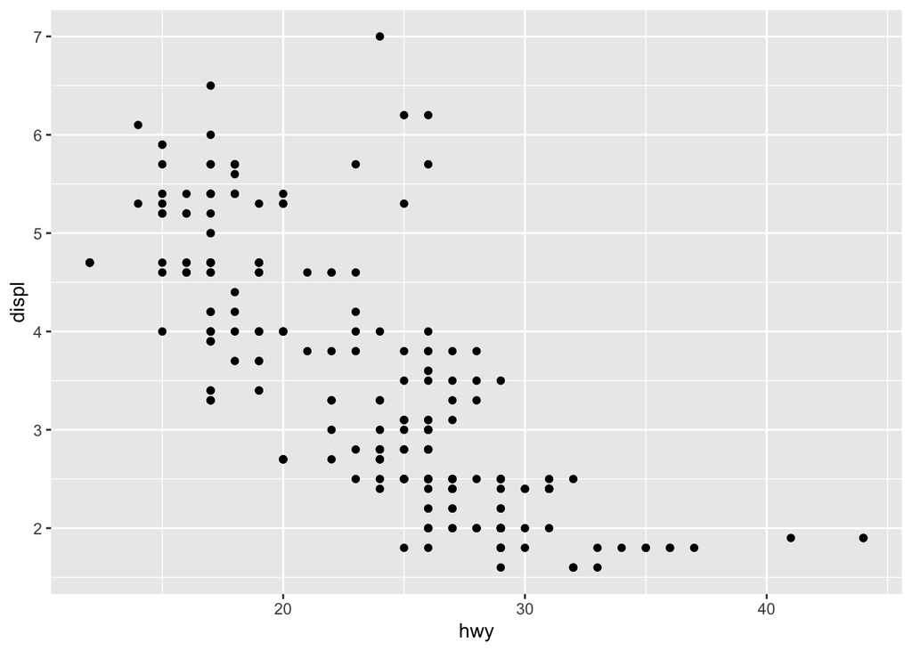

```r
# your code here
ggplot(data = mpg, aes(hwy, displ)) + geom_point()
```

Let’s restrict the data set to just cars manufactured by Audi.

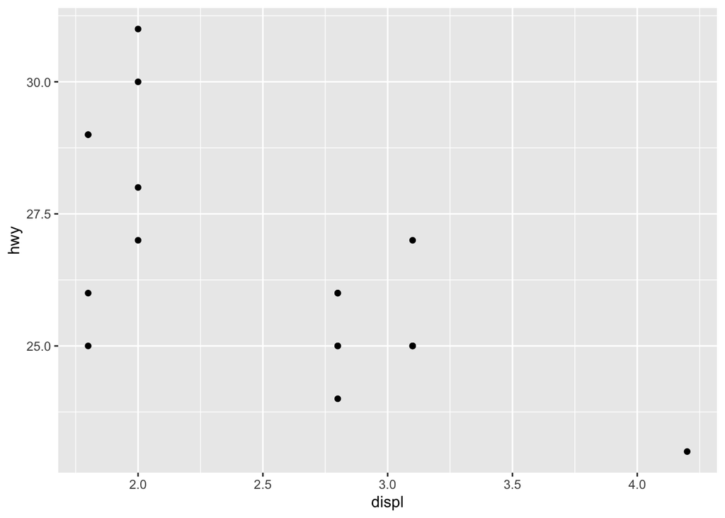

```r
audi <- mpg |> filter(manufacturer == 'audi')

ggplot(data = audi, aes(x = displ, y = hwy)) +
  geom_point()
```

### 1.1.2 Using `geom_text()`

Let’s label each point using the column `model`. Add a `geom_text()` layer, and don’t forget to put `aes()` in its argument.

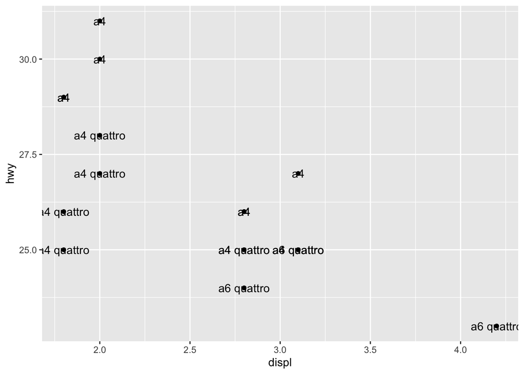

```r
# your code here
ggplot(data = audi, aes(x = displ, y = hwy)) +
  geom_point() +
  geom_text(aes(label = model))
```

The model names overlap with the points. Modify your code above by using the `nudge_y` argument in `geom_text()`. Does it go inside or outside of `aes()`?

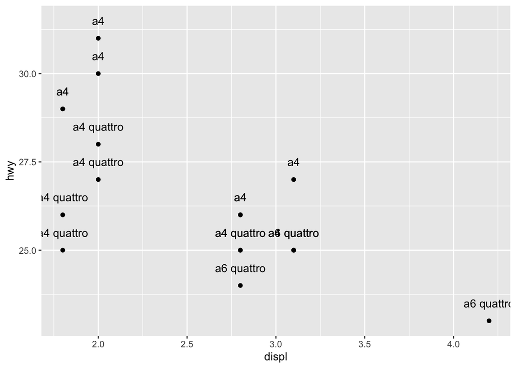

```r
# your code here
ggplot(data = audi, aes(x = displ, y = hwy)) +
  geom_point() +
  geom_text(aes(label = model), nudge_y = 0.5)
```

Now, replace `geom_text()` with `geom_label()`. What difference do you notice? Did you have to modify the arguments to `aes()` at all?

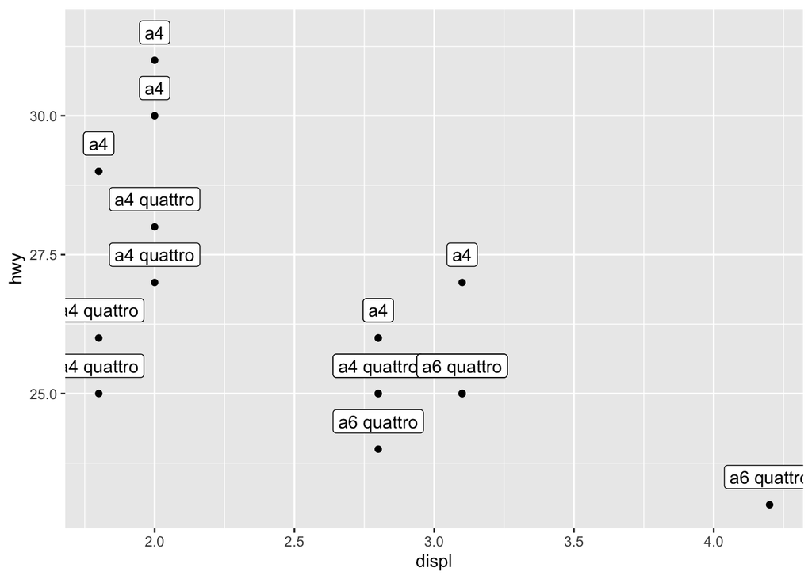

```r
# your code here
ggplot(data = audi, aes(x = displ, y = hwy)) +
  geom_point() +
  geom_label(aes(label = model), nudge_y = 0.5)
```

Next, cut and paste the `aes(x = displ, y = hwy)` from the argument of `ggplot()` to the argument of `geom_point()`. Do you run into an error? What if you copy the `x` and `y` arguments over to the `aes()` function in `geom_text()`?

```r
# error
ggplot(data = audi) +
  geom_point(aes(x = displ, y = hwy)) +
  geom_text(aes(label = model), nudge_y = 0.5)
```

```
Error in `geom_text()`:
! Problem while setting up geom.
ℹ Error occurred in the 2nd layer.
Caused by error in `compute_geom_1()`:
! `geom_text()` requires the following missing aesthetics: x and y.
```

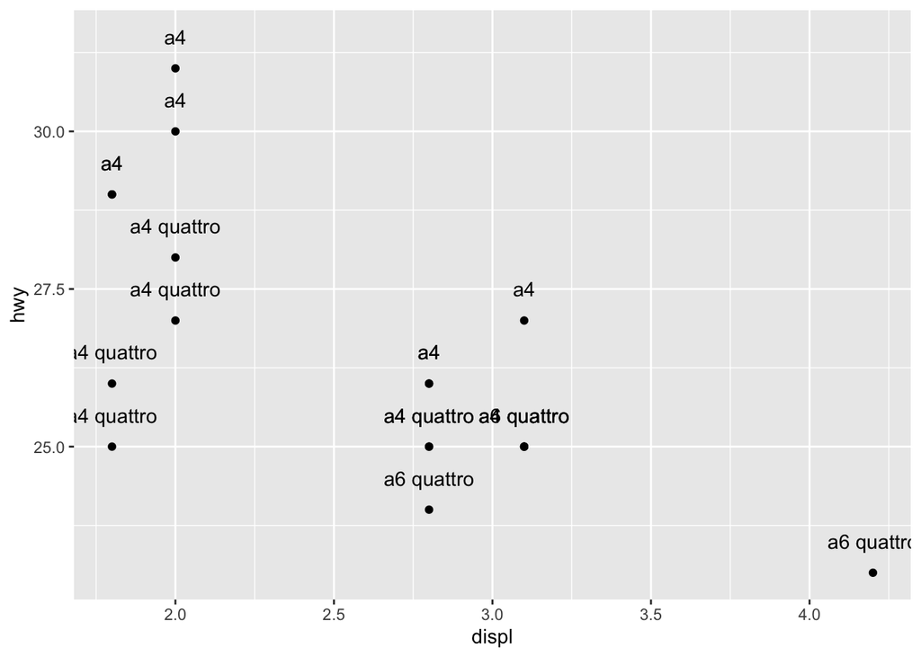

```r
# works
ggplot(data = audi) +
  geom_point(aes(x = displ, y = hwy)) +
  geom_text(aes(x = displ, y = hwy, label = model), nudge_y = 0.5)
```